# **Project Title**

Gold and silver Price Analysis and Prediction Using Python

**Introduction**

Gold and Silver is one the most important investment assets.

The project Analyze the Historic of the Gold and Silver price.

->Understand price trends

->Predict future prices using Linear Regression

**Objectives Load and clean the dataset**

Perform exploratory data analysis (EDA)

Visualize gold and silver price trends

Build a simple prediction model

Interpret results

**Technologies Used Python**

Pandas

NumPy

Matplotlib

Seaborn

Scikit-learn

**Step-by-Step Implementation (With Code)**

**Step 1: Import Required Libraries**

```python
import pandas as pd
import numpy as np
import matplotlib.pyplot as plt
import seaborn as sns
from sklearn.linear_model import LinearRegression
from sklearn.model_selection import train_test_split
from sklearn.metrics import mean_squared_error
```

**Step 2: Load Dataset**

```python
# Load dataset
df = pd.read_csv("Gold Futures Historical Data.csv")

# Display first 5 rows
print(df.head())
```

```
         Date     Price      Open      High       Low     Vol. Change %
0  02/20/2026  5,080.90  5,015.00  5,131.00  4,999.30  127.97K    1.67%
1  02/19/2026  4,997.40  4,993.70  5,042.80  4,971.50   87.03K   -0.24%
2  02/18/2026  5,009.50  4,898.50  5,031.90  4,868.50   98.20K    2.11%
3  02/17/2026  4,905.90  5,050.00  5,074.40  4,854.20  166.71K   -2.08%
4  02/16/2026  5,010.11  5,038.09  5,050.60  4,985.44   42.20K   -0.57%
```

```python
# Load dataset
df = pd.read_csv("silver Futures Historical Data.csv")

# Display first 5 rows
print(df.head())
```

```
         Date   Price    Open    High     Low    Vol. Change %
0  02/20/2026  82.343  78.475  84.645  77.285  55.40K    6.07%
1  02/19/2026  77.634  77.145  79.405  76.300  39.92K    0.05%
2  02/18/2026  77.598  73.580  78.320  72.250  46.41K    5.52%
3  02/17/2026  73.540  77.550  78.420  71.815  72.73K   -3.58%
4  02/16/2026  76.270  76.265  77.438  74.685  15.77K   -0.02%
```

**Step 3: Data Cleaning**

```python
# Check dataset info
print(df.info())

# Convert Date column to datetime
df['Date'] = pd.to_datetime(df['Date'])
```

[output not shown]

```python
# sort by Date
df = df.sort_values('Date')
#check the null values
print(df.isnull().sum)
```

[output not shown]

**Step 4: Exploratory Data Analysis(EDA)**

[figure not shown]

```python
plt.figure()
plt.plot(df['Date'], df['Price'])
plt.title("Gold Price Trend Over Time")
plt.xlabel("Date")
plt.ylabel("Price")
plt.xticks(rotation=45)
plt.show()
```

**Plot Silver Price Trend**

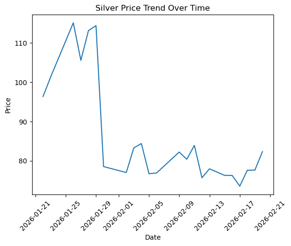

```python
plt.figure()
plt.plot(df['Date'], df['Price'])
plt.title("Silver Price Trend Over Time")
plt.xlabel("Date")
plt.ylabel("Price")
plt.xticks(rotation=45)
plt.show()
```

```python
print(df['price'].describe())
```

[output not shown]

**Daily Returns calculation**

[figure not shown]

```python
df['Daily_Return'] = df['Price'].pct_change()

plt.figure()
plt.plot(df['Date'], df['Daily_Return'])
plt.title("Daily Returns of Gold")
plt.xlabel("Date")
plt.ylabel("Return")
plt.xticks(rotation=45)
plt.show()
```

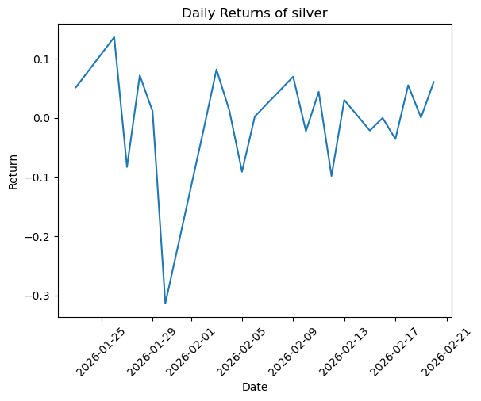

```python
df['Daily_Return'] = df['Price'].pct_change()

plt.figure()
plt.plot(df['Date'], df['Daily_Return'])
plt.title("Daily Returns of silver")
plt.xlabel("Date")
plt.ylabel("Return")
plt.xticks(rotation=45)
plt.show()
```

**Step 5: Price Prediction Model**

We will use **Liner Regressio** to Predict Future prices.

**Step 6: Prepare Data for Model**

# Create numeric index for dates

df['Days'] = (df['Date'] - df['Date'].min()).dt.days

# Split dataset

X_train, X_test, y_train, y_test = train_test_split(X, y, test_size=0.2, random_state=42)

**Step 7: Train Model**

```python
model = LinearRegression()
model.fit(X_train, y_train)

# Predictions
y_pred = model.predict(X_test)

# Model accuracy
mse = mean_squared_error(y_test, y_pred)
print("Mean Squared Error:", mse)
```

```
Mean Squared Error: 47.505127732380835
```

**Step :8 Visualize Prediction**

[figure not shown]

```python
plt.figure()
plt.scatter(X_test, y_test)
plt.plot(X_test, y_pred)
plt.title("Actual vs Predicted Gold Prices")
plt.xlabel("Days")
plt.ylabel("Price")
plt.show()
```

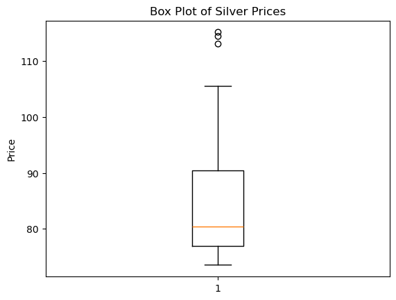

```python
plt.figure()

plt.boxplot(df['Price'])

plt.title("Box Plot of Silver Prices")
plt.ylabel("Price")
plt.show()
```

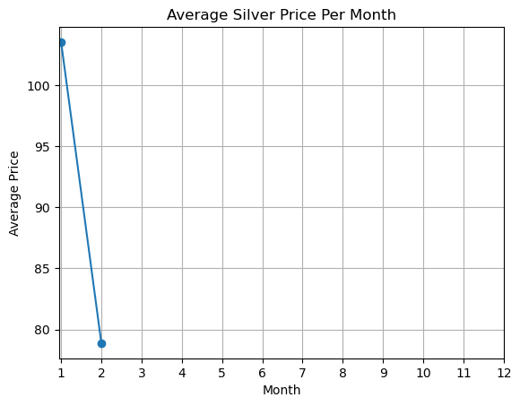

```python
# Extract Month
df['Month'] = df['Date'].dt.month

# Calculate monthly average price
monthly_avg = df.groupby('Month')['Price'].mean()

# Plot Line Chart
plt.figure()

plt.plot(monthly_avg.index, monthly_avg.values, marker='o')

plt.title("Average Silver Price Per Month")
plt.xlabel("Month")
plt.ylabel("Average Price")
plt.xticks(range(1,13))  # Show all months
plt.grid(True)

plt.show()
```

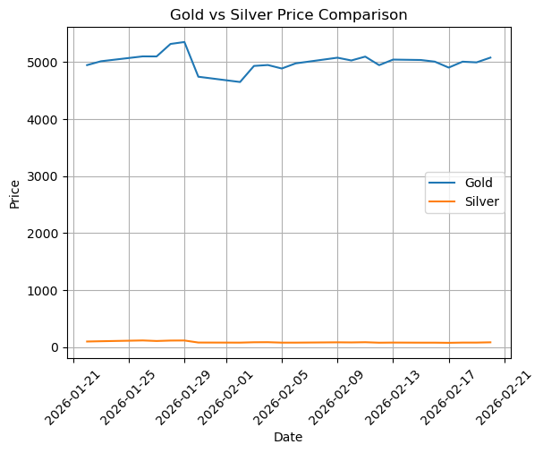

```python
import pandas as pd
import matplotlib.pyplot as plt

# Load datasets
gold = pd.read_csv("Gold Futures Historical Data.csv")
silver = pd.read_csv("Silver Futures Historical Data.csv")

# Convert Date column
gold['Date'] = pd.to_datetime(gold['Date'])
silver['Date'] = pd.to_datetime(silver['Date'])

# Clean Price column (remove commas)
gold['Price'] = gold['Price'].astype(str).str.replace(',', '').astype(float)
silver['Price'] = silver['Price'].astype(str).str.replace(',', '').astype(float)

# Sort by Date
gold = gold.sort_values('Date')
silver = silver.sort_values('Date')

# Merge datasets on Date
merged = pd.merge(gold[['Date', 'Price']],
                  silver[['Date', 'Price']],
                  on='Date',
                  suffixes=('_Gold', '_Silver'))

# Plot comparison
plt.figure()

plt.plot(merged['Date'], merged['Price_Gold'])
plt.plot(merged['Date'], merged['Price_Silver'])

plt.title("Gold vs Silver Price Comparison")
plt.xlabel("Date")
plt.ylabel("Price")
plt.legend(["Gold", "Silver"])

plt.xticks(rotation=45)
plt.grid(True)

plt.show()
```

**Results of Gold and Silver Comparison**

⃣ **Volatility Comparison**

Silver prices fluctuate more frequently and sharply.

Gold is comparatively more stable and less volatile.

Silver = High Risk, High FluctuationGold = Stable Investment

**Conclusion**

Silver offers higher short-term opportunities but with higher risk.